# Homework #1

David Nemirovsky

2/14/21

In this exercise, we will predict solubility of compounds using their chemical structures. The training data are in the file “solubility_train.csv” and the test data are in “solubility_test.csv”. Among the 228 predictors, 208 are binary variables that indicate the presence or absence of a particular chemical substructure, 16 are count features, such as the number of bonds or the number of bromine atoms, and 4 are continuous features, such as molecular weight or surface area. The response is in the column “Solubility” (the last column).

1. Fit a linear model using least squares on the training data and calculate the mean squared error using the test data.
- First, let’s read in the data:

```r
train_df = read_csv("solubility_train.csv")
test_df = read_csv("solubility_test.csv")
```

- Next, let’s create a linear model with 10-fold CV:

```r
set.seed(37564)
ctrl = trainControl(method = "cv", number = 10)
model_lm = train(Solubility~.,
               data = train_df,
               method = "lm",
               trControl = ctrl)

model_lm$finalModel$coefficients %>%
  broom::tidy() %>%
  knitr::kable(col.names = c("Predictor", "Beta Value"))
```

| Predictor | Beta Value |
| --- | --- |
| (Intercept) | 2.4307073 |
| FP001 | 0.3593637 |
| FP002 | 0.1455962 |
| FP003 | -0.0396932 |
| FP004 | -0.3048941 |
| FP005 | 2.8367245 |
| FP006 | -0.0688605 |
| FP007 | 0.0404391 |
| FP008 | 0.1121160 |
| FP009 | -0.8242261 |
| FP010 | 0.4193129 |
| FP011 | 0.0515819 |
| FP012 | -0.0134551 |
| FP013 | -0.4518555 |
| FP014 | 0.3281228 |
| FP015 | -0.1839154 |
| FP016 | -0.1367002 |
| FP017 | -0.1704358 |
| FP018 | -0.3824335 |
| FP019 | -0.3131000 |
| FP020 | 0.2071759 |
| FP021 | -0.0595630 |
| FP022 | 0.2336336 |
| FP023 | -0.3193254 |
| FP024 | -0.4272191 |
| FP025 | 0.4376374 |
| FP026 | 0.2067680 |
| FP027 | 0.2423901 |
| FP028 | 0.1070430 |
| FP029 | -0.0985727 |

[output cut: 199 more lines]

- Now, let’s calculate the MSE using the test data:

```r
lm_pred = predict(model_lm, newdata = test_df)
mse_lm = mean((lm_pred - test_df$Solubility)^2)
```

- Therefore, the MSE of this linear model is **0.5559**.
2. Fit a ridge regression model on the training data, with $\lambda$ chosen by cross-validation. Report the test error.
- Use `glmnet` to identify tuning parameters for $\lambda$, then fit a 10-fold CV ridge model on training data:

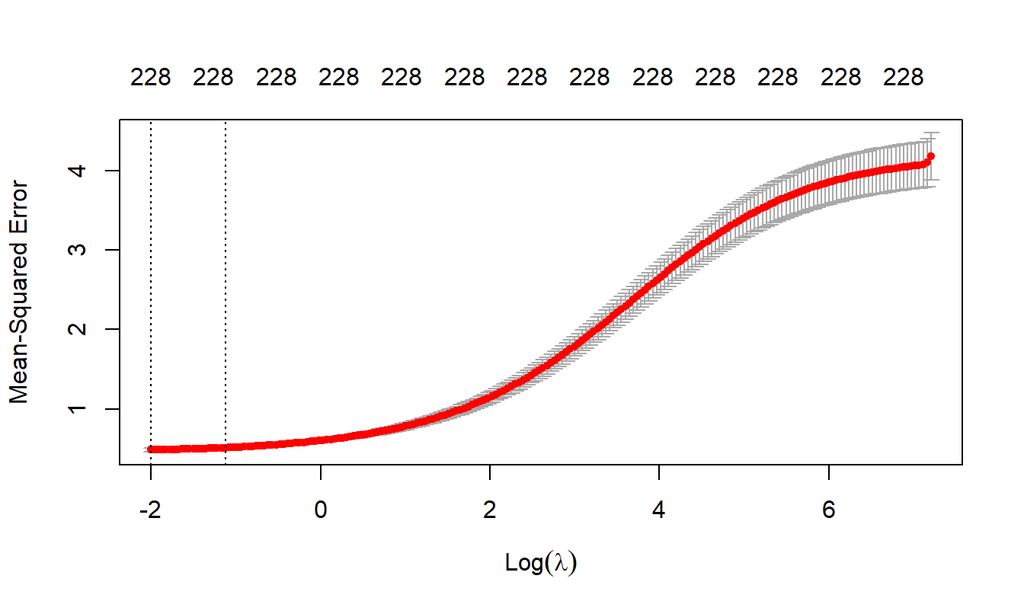

```r
set.seed(37564)

x = model.matrix(Solubility ~ ., train_df)[ ,-1]
y = train_df$Solubility

tuning_model = cv.glmnet(x, y, alpha = 0, nlambda = 200)
plot(tuning_model)
```

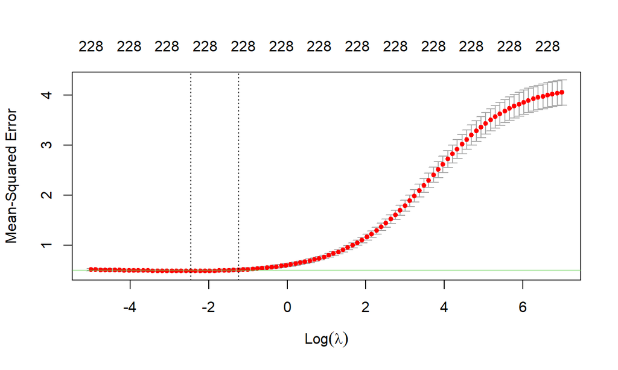

```r
#Set lambda parameters:
model_ridge = cv.glmnet(x, y, alpha = 0, lambda = exp(seq(7, -5, length = 100)))

plot(model_ridge)
abline(h = (model_ridge$cvm + model_ridge$cvsd)[which.min(model_ridge$cvm)], col = 3, lwd = 0.1)
```

```r
coef_ridge = predict(model_ridge, s = model_ridge$lambda.min, type = "coefficients")
coef_ridge %>%
  broom::tidy() %>%
  select(row, value) %>%
  knitr::kable(col.names = c("Predictor", "Beta Value"))
```

| Predictor | Beta Value |
| --- | --- |
| (Intercept) | 8.1301777 |
| FP001 | 0.0295179 |
| FP002 | 0.1487592 |
| FP003 | -0.0887863 |
| FP004 | -0.2269673 |
| FP005 | -0.0163652 |
| FP006 | -0.1222361 |
| FP007 | 0.0257340 |
| FP008 | 0.0460557 |
| FP009 | 0.0002154 |
| FP010 | 0.0669760 |
| FP011 | 0.1132827 |
| FP012 | -0.0794803 |
| FP013 | -0.0886011 |
| FP014 | 0.0255280 |
| FP015 | -0.0617704 |
| FP016 | -0.1277201 |
| FP017 | -0.2083927 |
| FP018 | -0.1907529 |
| FP019 | -0.0049202 |
| FP020 | 0.1506450 |
| FP021 | 0.0067597 |
| FP022 | 0.1546293 |
| FP023 | -0.1933705 |
| FP024 | -0.1734084 |
| FP025 | 0.0367592 |
| FP026 | 0.1743906 |
| FP027 | 0.2345027 |
| FP028 | 0.0770580 |
| FP029 | -0.0588067 |

[output cut: 199 more lines]

- Using the above ridge model, the $\lambda_{min}$ was found to be **0.0859** and the $\lambda_{1SE}$ was found to be **0.2887**.
- Now, calculate the MSE of the ridge model:

```r
x_test = model.matrix(Solubility ~ ., test_df)[ ,-1]
ridge_pred = predict(model_ridge, newx = x_test,
             s = "lambda.min", type = "response")
mse_ridge = mean((ridge_pred - test_df$Solubility)^2)
```

- Therefore, the MSE of this ridge regression model, using $\lambda_{min}$, is **0.5112**.
3. Fit a lasso model on the training data, with $\lambda$ chosen by cross-validation. Report the test error and the number of non-zero coeffcient estimates in your model.
- Use `glmnet` to identify tuning parameters for $\lambda$, then fit a 10-fold CV lasso model on training data:

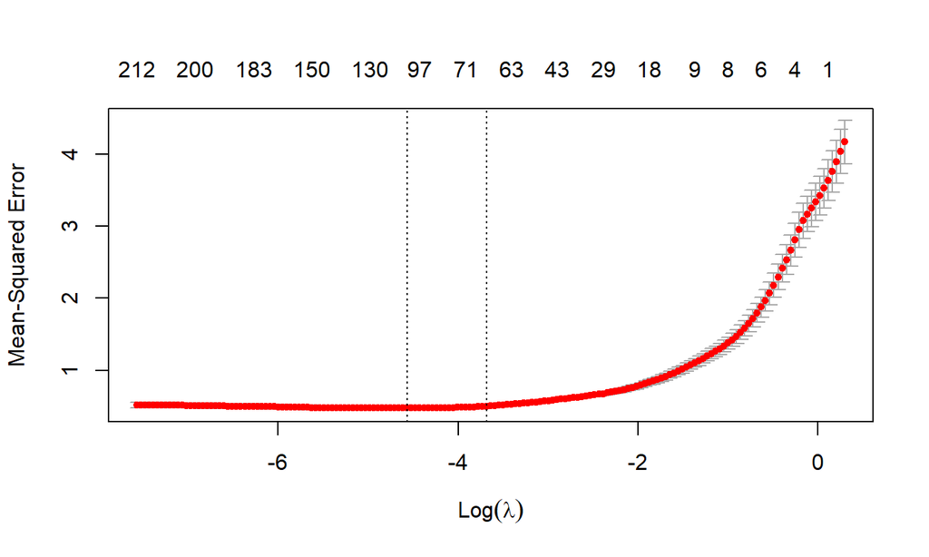

```r
set.seed(37564)

tuning_model2 = cv.glmnet(x, y, alpha = 1, nlambda = 200)
plot(tuning_model2)
```

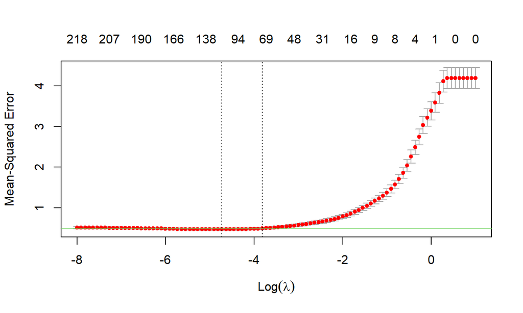

```r
#Set lambda parameters:
model_lasso = cv.glmnet(x, y, alpha = 1, lambda = exp(seq(1, -8, length = 100)))

plot(model_lasso)
abline(h = (model_lasso$cvm + model_lasso$cvsd)[which.min(model_lasso$cvm)], col = 3, lwd = 0.1)
```

```r
coef_lasso = predict(model_lasso, s = model_lasso$lambda.min, type = "coefficients")
pred_names = coef_ridge %>% broom::tidy() %>% select(row)
coef_lasso[ ,1] %>%
  as_tibble() %>%
  cbind(pred_names) %>%
  select(row, value) %>%
  knitr::kable(col.names = c("Predictor", "Beta Value"))
```

| Predictor | Beta Value |
| --- | --- |
| (Intercept) | 7.6392836 |
| FP001 | 0.0000000 |
| FP002 | 0.2258217 |
| FP003 | -0.0032851 |
| FP004 | -0.1577687 |
| FP005 | 0.0000000 |
| FP006 | -0.0021433 |
| FP007 | 0.0000000 |
| FP008 | 0.0000000 |
| FP009 | 0.0000000 |
| FP010 | 0.0000000 |
| FP011 | 0.0000000 |
| FP012 | -0.0017521 |
| FP013 | -0.0404272 |
| FP014 | 0.0000000 |
| FP015 | -0.0328297 |
| FP016 | -0.0391358 |
| FP017 | -0.0592403 |
| FP018 | -0.0005796 |
| FP019 | 0.0000000 |
| FP020 | 0.0000000 |
| FP021 | 0.0000000 |
| FP022 | 0.0518513 |
| FP023 | -0.0838433 |
| FP024 | 0.0000000 |
| FP025 | -0.0081192 |
| FP026 | 0.2879538 |
| FP027 | 0.1991662 |
| FP028 | 0.0000000 |
| FP029 | 0.0000000 |

[output cut: 199 more lines]

- Using the above ridge model, the $\lambda_{min}$ was found to be **0.0089** and the $\lambda_{1SE}$ was found to be **0.022**. There are **119** non-zero estimates in the lasso model.
- Now, calculate the MSE of the lasso model:

```r
lasso_pred = predict(model_lasso, newx = x_test,
             s = "lambda.min", type = "response")
mse_lasso = mean((lasso_pred - test_df$Solubility)^2)
```

- Therefore, the MSE of this lasso regression model, using $\lambda_{min}$ with 119 predictors, is **0.4949**.
4. Fit a principle component regression model on the training data, with M chosen by cross-validation. Report the test error and the value ofM selected by cross-validation.
- Using `pls` package, fit a PCR model on the training data to determine appropriate number of components that best fit the model:

```r
set.seed(37564)
model_pcr = pcr(Solubility ~ ., data = train_df, scale = TRUE, validation = "CV")
cv_mse = RMSEP(model_pcr)
ncomp_pcr = which.min(cv_mse$val[1,,]) - 1
ncomp_pcr
```

```
## 159 comps
##       159
```

- Now, calculate the MSE of the PCR model:

```r
pcr_pred = predict(model_pcr, newdata = test_df,
ncomp = ncomp_pcr)
mse_pcr = mean((pcr_pred - test_df$Solubility)^2)
```

- Therefore, the MSE of this PCR model, using 159 components is **0.5467**.
5. Which model will you choose for predicting solubility?
- Generate table to compare MSE values of models:

```r
tibble(
  Model = c("Linear", "Ridge", "Lasso", "PCR"),
  MSE = c(mse_lm[1], mse_ridge[1], mse_lasso[1], mse_pcr[1])
) %>%
  knitr::kable()
```

| Model | MSE |
| --- | --- |
| Linear | 0.5558898 |
| Ridge | 0.5112081 |
| Lasso | 0.4949164 |
| PCR | 0.5466861 |

- Therefore, I would choose the lasso model for predicting solubility because it gives the lowest MSE using the testing data.